# *Boosting Claims Predictions: an Analysis on Kaggle Data*

# Abstract

Predictive modeling on data from the Porto Seguro’s Safe Driver Prediction competition hosted on the Kaggle platform is performed leveraging machine learning boosting algorithms (`AdaBoost` and `XGBoost`). We refer to the document "On Boosting: Theory and Applications" to complement the analysis presented in this notebook.

# Getting Started with Python and Jupyter Notebook

In this section, Jupyter Notebook and Python settings are initialized. For code in Python, the [PEP8 standard](https://www.python.org/dev/peps/pep-0008/) ("PEP = Python Enhancement Proposal") is enforced with minor variations to improve readibility.

```python
# Notebook settings
###################

# resetting variables
get_ipython().magic('reset -sf')

# formatting: cell width
from IPython.core.display import display, HTML
display(HTML("<style>.container { width:100% !important; }</style>"))

# plotting
%matplotlib inline
```

```python
# importing xgboost REMARK: run this cell only if other imports failed. Delete it in case xgboost has been already imported
# import pip
# pip.main(['install', 'xgboost'])
```

```python
# loading Python packages
#########################

# scientific packages
import pandas as pd
import numpy as np
import matplotlib.pyplot as plt
import seaborn as sns
import sklearn
import scipy

# boosting
import xgboost
from xgboost import XGBClassifier
from xgboost import plot_importance

# scipy
from scipy.stats import chi2

# pandas: selected modules and functions
from pandas.plotting import scatter_matrix

# sklearn: selected modules and functions
from sklearn import decomposition
from sklearn.decomposition import PCA

from sklearn.preprocessing import Imputer
from sklearn.preprocessing import PolynomialFeatures
from sklearn.preprocessing import StandardScaler
from sklearn.preprocessing import scale

from sklearn.tree import DecisionTreeClassifier
from sklearn.ensemble import AdaBoostClassifier

from sklearn.utils import shuffle

from sklearn.feature_selection import VarianceThreshold
from sklearn.feature_selection import SelectFromModel

from sklearn.model_selection import train_test_split
from sklearn.model_selection import StratifiedKFold
from sklearn.model_selection import GridSearchCV

from sklearn.linear_model import LogisticRegression
from sklearn.tree import DecisionTreeClassifier
from sklearn.ensemble import RandomForestClassifier, AdaBoostClassifier
from sklearn.pipeline import Pipeline

from sklearn.metrics import roc_curve
from sklearn.metrics import auc
from sklearn.metrics import roc_auc_score
from sklearn.metrics import accuracy_score
from sklearn.metrics import precision_score
from sklearn.metrics import recall_score
from sklearn.metrics import classification_report
from sklearn.metrics import zero_one_loss

# utilities
from datetime import datetime
```

# Data Import

For the given Kaggle competition, two datasets are provided, one for training data and the other for generating predictions to be submitted. The latter lacks of the target variable (denoted by `target` in the former): it will not be imported in this notebook. Therefore, the whole analysis is carried out on the original 'training' data. A remark on data acquisition procedure: a direct download from the Kaggle [Porto Seguro Challenge website](https://www.kaggle.com/c/porto-seguro-safe-driver-prediction/data) in a landing folder on a local machine is performed; original data are then copied in a separate folder and there unzipped. Import of unzipped data is performed using `pandas` as follows:

```python
# data import: specify the path to the competition training data
path = 'D:\\学习资料 RUC 硕\\硕一上\\现代统计精算模型\\boosting\\train.csv'
data = pd.read_csv(path)
```

Imported dataset, i.e. `data`, comprises of 595212 records and 59 columns:

```python
print('Structure of imported data:', data.shape)
```

```
Structure of imported data: (595212, 59)
```

Memory usage of `data`:

```python
print('Memory usage of `data` (in bytes):', pd.DataFrame.memory_usage(data, index=True, deep=True).sum())
```

```
Memory usage of `data` (in bytes): 280940144
```

# Structural Data Analysis

From the data description on the Kaggle [Porto Seguro Challenge website](https://www.kaggle.com/c/porto-seguro-safe-driver-prediction/data) the following information on the features in `data` are provided:

- Features that belong to similar groupings are tagged as such in the feature names (e.g., `ind`, `reg`, `car`, `calc`).
- Feature names include the postfix `bin` to indicate binary features and `cat` to indicate categorical features.
- Features without these designations are either continuous or ordinal.
- Values of `-1` indicate that the feature was missing from the observation.
- The target column `target` signifies whether or not a claim was filed for that policy holder.

The variable `target` is therefore the label used to train the classifiers. Data types for all columns in `data` are shown below:

```python
# data types
data.info()
```

```
<class 'pandas.core.frame.DataFrame'>
RangeIndex: 595212 entries, 0 to 595211
Data columns (total 59 columns):
id                595212 non-null int64
target            595212 non-null int64
ps_ind_01         595212 non-null int64
ps_ind_02_cat     595212 non-null int64
ps_ind_03         595212 non-null int64
ps_ind_04_cat     595212 non-null int64
ps_ind_05_cat     595212 non-null int64
ps_ind_06_bin     595212 non-null int64
ps_ind_07_bin     595212 non-null int64
ps_ind_08_bin     595212 non-null int64
ps_ind_09_bin     595212 non-null int64
ps_ind_10_bin     595212 non-null int64
ps_ind_11_bin     595212 non-null int64
ps_ind_12_bin     595212 non-null int64
ps_ind_13_bin     595212 non-null int64
ps_ind_14         595212 non-null int64
ps_ind_15         595212 non-null int64
ps_ind_16_bin     595212 non-null int64
ps_ind_17_bin     595212 non-null int64
ps_ind_18_bin     595212 non-null int64
ps_reg_01         595212 non-null float64
ps_reg_02         595212 non-null float64
ps_reg_03         595212 non-null float64
ps_car_01_cat     595212 non-null int64
ps_car_02_cat     595212 non-null int64
ps_car_03_cat     595212 non-null int64
ps_car_04_cat     595212 non-null int64
ps_car_05_cat     595212 non-null int64
ps_car_06_cat     595212 non-null int64
ps_car_07_cat     595212 non-null int64
ps_car_08_cat     595212 non-null int64
ps_car_09_cat     595212 non-null int64
ps_car_10_cat     595212 non-null int64
ps_car_11_cat     595212 non-null int64
ps_car_11         595212 non-null int64
ps_car_12         595212 non-null float64
ps_car_13         595212 non-null float64
```

[output cut: 9 more lines]

```
ps_calc_08        595212 non-null int64
ps_calc_09        595212 non-null int64
ps_calc_10        595212 non-null int64
ps_calc_11        595212 non-null int64
ps_calc_12        595212 non-null int64
ps_calc_13        595212 non-null int64
ps_calc_14        595212 non-null int64
ps_calc_15_bin    595212 non-null int64
ps_calc_16_bin    595212 non-null int64
ps_calc_17_bin    595212 non-null int64
ps_calc_18_bin    595212 non-null int64
ps_calc_19_bin    595212 non-null int64
ps_calc_20_bin    595212 non-null int64
dtypes: float64(10), int64(49)
memory usage: 267.9 MB
```

Both integer and float data types are present; the variable `id` uniquely identifies data records; a quick check shows that no duplicate record exists:

```python
# duplicates? None
data.drop_duplicates().shape
```

```
(595212, 59)
```

One continues by checking the first 10 entries of the `data` dataset before moving to a high level summary using `describe()`.

```python
# imported data: first 10 entries
data.head(10).T
```

|  | 0 | 1 | 2 | 3 | 4 | 5 | 6 | 7 | 8 | 9 |
| --- | --- | --- | --- | --- | --- | --- | --- | --- | --- | --- |
| id | 7.000000 | 9.000000 | 13.000000 | 16.000000 | 17.000000 | 19.000000 | 20.000000 | 22.000000 | 26.000000 | 28.000000 |
| target | 0.000000 | 0.000000 | 0.000000 | 0.000000 | 0.000000 | 0.000000 | 0.000000 | 0.000000 | 0.000000 | 1.000000 |
| ps_ind_01 | 2.000000 | 1.000000 | 5.000000 | 0.000000 | 0.000000 | 5.000000 | 2.000000 | 5.000000 | 5.000000 | 1.000000 |
| ps_ind_02_cat | 2.000000 | 1.000000 | 4.000000 | 1.000000 | 2.000000 | 1.000000 | 1.000000 | 1.000000 | 1.000000 | 1.000000 |
| ps_ind_03 | 5.000000 | 7.000000 | 9.000000 | 2.000000 | 0.000000 | 4.000000 | 3.000000 | 4.000000 | 3.000000 | 2.000000 |
| ps_ind_04_cat | 1.000000 | 0.000000 | 1.000000 | 0.000000 | 1.000000 | 0.000000 | 1.000000 | 0.000000 | 1.000000 | 0.000000 |
| ps_ind_05_cat | 0.000000 | 0.000000 | 0.000000 | 0.000000 | 0.000000 | 0.000000 | 0.000000 | 0.000000 | 0.000000 | 0.000000 |
| ps_ind_06_bin | 0.000000 | 0.000000 | 0.000000 | 1.000000 | 1.000000 | 0.000000 | 0.000000 | 1.000000 | 0.000000 | 0.000000 |
| ps_ind_07_bin | 1.000000 | 0.000000 | 0.000000 | 0.000000 | 0.000000 | 0.000000 | 1.000000 | 0.000000 | 0.000000 | 1.000000 |
| ps_ind_08_bin | 0.000000 | 1.000000 | 1.000000 | 0.000000 | 0.000000 | 0.000000 | 0.000000 | 0.000000 | 1.000000 | 0.000000 |
| ps_ind_09_bin | 0.000000 | 0.000000 | 0.000000 | 0.000000 | 0.000000 | 1.000000 | 0.000000 | 0.000000 | 0.000000 | 0.000000 |
| ps_ind_10_bin | 0.000000 | 0.000000 | 0.000000 | 0.000000 | 0.000000 | 0.000000 | 0.000000 | 0.000000 | 0.000000 | 0.000000 |
| ps_ind_11_bin | 0.000000 | 0.000000 | 0.000000 | 0.000000 | 0.000000 | 0.000000 | 0.000000 | 0.000000 | 0.000000 | 0.000000 |
| ps_ind_12_bin | 0.000000 | 0.000000 | 0.000000 | 0.000000 | 0.000000 | 0.000000 | 0.000000 | 0.000000 | 0.000000 | 0.000000 |
| ps_ind_13_bin | 0.000000 | 0.000000 | 0.000000 | 0.000000 | 0.000000 | 0.000000 | 0.000000 | 0.000000 | 0.000000 | 0.000000 |
| ps_ind_14 | 0.000000 | 0.000000 | 0.000000 | 0.000000 | 0.000000 | 0.000000 | 0.000000 | 0.000000 | 0.000000 | 0.000000 |
| ps_ind_15 | 11.000000 | 3.000000 | 12.000000 | 8.000000 | 9.000000 | 6.000000 | 8.000000 | 13.000000 | 6.000000 | 4.000000 |
| ps_ind_16_bin | 0.000000 | 0.000000 | 1.000000 | 1.000000 | 1.000000 | 1.000000 | 1.000000 | 1.000000 | 1.000000 | 0.000000 |
| ps_ind_17_bin | 1.000000 | 0.000000 | 0.000000 | 0.000000 | 0.000000 | 0.000000 | 0.000000 | 0.000000 | 0.000000 | 0.000000 |
| ps_ind_18_bin | 0.000000 | 1.000000 | 0.000000 | 0.000000 | 0.000000 | 0.000000 | 0.000000 | 0.000000 | 0.000000 | 1.000000 |
| ps_reg_01 | 0.700000 | 0.800000 | 0.000000 | 0.900000 | 0.700000 | 0.900000 | 0.600000 | 0.700000 | 0.900000 | 0.900000 |
| ps_reg_02 | 0.200000 | 0.400000 | 0.000000 | 0.200000 | 0.600000 | 1.800000 | 0.100000 | 0.400000 | 0.700000 | 1.400000 |
| ps_reg_03 | 0.718070 | 0.766078 | -1.000000 | 0.580948 | 0.840759 | 2.332649 | 0.617454 | 0.607248 | 0.901388 | 2.316652 |
| ps_car_01_cat | 10.000000 | 11.000000 | 7.000000 | 7.000000 | 11.000000 | 10.000000 | 6.000000 | 11.000000 | 10.000000 | 11.000000 |
| ps_car_02_cat | 1.000000 | 1.000000 | 1.000000 | 1.000000 | 1.000000 | 0.000000 | 1.000000 | 1.000000 | 1.000000 | 0.000000 |
| ps_car_03_cat | -1.000000 | -1.000000 | -1.000000 | 0.000000 | -1.000000 | -1.000000 | -1.000000 | 0.000000 | -1.000000 | 0.000000 |
| ps_car_04_cat | 0.000000 | 0.000000 | 0.000000 | 0.000000 | 0.000000 | 0.000000 | 0.000000 | 0.000000 | 0.000000 | 1.000000 |
| ps_car_05_cat | 1.000000 | -1.000000 | -1.000000 | 1.000000 | -1.000000 | 0.000000 | 1.000000 | 0.000000 | 1.000000 | 0.000000 |
| ps_car_06_cat | 4.000000 | 11.000000 | 14.000000 | 11.000000 | 14.000000 | 14.000000 | 11.000000 | 11.000000 | 14.000000 | 14.000000 |
| ps_car_07_cat | 1.000000 | 1.000000 | 1.000000 | 1.000000 | 1.000000 | 1.000000 | 1.000000 | 1.000000 | 1.000000 | 1.000000 |
| ps_car_08_cat | 0.000000 | 1.000000 | 1.000000 | 1.000000 | 1.000000 | 1.000000 | 1.000000 | 1.000000 | 1.000000 | 1.000000 |
| ps_car_09_cat | 0.000000 | 2.000000 | 2.000000 | 3.000000 | 2.000000 | 0.000000 | 0.000000 | 2.000000 | 0.000000 | 2.000000 |
| ps_car_10_cat | 1.000000 | 1.000000 | 1.000000 | 1.000000 | 1.000000 | 1.000000 | 1.000000 | 1.000000 | 1.000000 | 1.000000 |
| ps_car_11_cat | 12.000000 | 19.000000 | 60.000000 | 104.000000 | 82.000000 | 104.000000 | 99.000000 | 30.000000 | 68.000000 | 104.000000 |
| ps_car_11 | 2.000000 | 3.000000 | 1.000000 | 1.000000 | 3.000000 | 2.000000 | 2.000000 | 3.000000 | 3.000000 | 2.000000 |
| ps_car_12 | 0.400000 | 0.316228 | 0.316228 | 0.374166 | 0.316070 | 0.445982 | 0.316228 | 0.446990 | 0.400000 | 0.447214 |
| ps_car_13 | 0.883679 | 0.618817 | 0.641586 | 0.542949 | 0.565832 | 0.879049 | 0.639683 | 0.900574 | 0.780641 | 1.458184 |
| ps_car_14 | 0.370810 | 0.388716 | 0.347275 | 0.294958 | 0.365103 | 0.406202 | 0.368782 | 0.374833 | 0.407431 | 0.390256 |
| ps_car_15 | 3.605551 | 2.449490 | 3.316625 | 2.000000 | 2.000000 | 3.000000 | 3.162278 | 3.316625 | 2.828427 | 3.605551 |
| ps_calc_01 | 0.600000 | 0.300000 | 0.500000 | 0.600000 | 0.400000 | 0.700000 | 0.200000 | 0.100000 | 0.900000 | 0.700000 |
| ps_calc_02 | 0.500000 | 0.100000 | 0.700000 | 0.900000 | 0.600000 | 0.800000 | 0.600000 | 0.500000 | 0.800000 | 0.800000 |
| ps_calc_03 | 0.200000 | 0.300000 | 0.100000 | 0.100000 | 0.000000 | 0.400000 | 0.500000 | 0.100000 | 0.600000 | 0.800000 |
| ps_calc_04 | 3.000000 | 2.000000 | 2.000000 | 2.000000 | 2.000000 | 3.000000 | 2.000000 | 1.000000 | 3.000000 | 2.000000 |
| ps_calc_05 | 1.000000 | 1.000000 | 2.000000 | 4.000000 | 2.000000 | 1.000000 | 2.000000 | 2.000000 | 1.000000 | 2.000000 |
| ps_calc_06 | 10.000000 | 9.000000 | 9.000000 | 7.000000 | 6.000000 | 8.000000 | 8.000000 | 7.000000 | 7.000000 | 8.000000 |
| ps_calc_07 | 1.000000 | 5.000000 | 1.000000 | 1.000000 | 3.000000 | 2.000000 | 1.000000 | 1.000000 | 3.000000 | 2.000000 |
| ps_calc_08 | 10.000000 | 8.000000 | 8.000000 | 8.000000 | 10.000000 | 11.000000 | 8.000000 | 6.000000 | 9.000000 | 9.000000 |
| ps_calc_09 | 1.000000 | 1.000000 | 2.000000 | 4.000000 | 2.000000 | 3.000000 | 3.000000 | 1.000000 | 4.000000 | 1.000000 |
| ps_calc_10 | 5.000000 | 7.000000 | 7.000000 | 2.000000 | 12.000000 | 8.000000 | 10.000000 | 13.000000 | 11.000000 | 11.000000 |
| ps_calc_11 | 9.000000 | 3.000000 | 4.000000 | 2.000000 | 3.000000 | 4.000000 | 3.000000 | 7.000000 | 4.000000 | 3.000000 |
| ps_calc_12 | 1.000000 | 1.000000 | 2.000000 | 2.000000 | 1.000000 | 2.000000 | 0.000000 | 1.000000 | 2.000000 | 5.000000 |
| ps_calc_13 | 5.000000 | 1.000000 | 7.000000 | 4.000000 | 1.000000 | 0.000000 | 0.000000 | 3.000000 | 1.000000 | 0.000000 |
| ps_calc_14 | 8.000000 | 9.000000 | 7.000000 | 9.000000 | 3.000000 | 9.000000 | 10.000000 | 6.000000 | 5.000000 | 6.000000 |
| ps_calc_15_bin | 0.000000 | 0.000000 | 0.000000 | 0.000000 | 0.000000 | 0.000000 | 0.000000 | 1.000000 | 0.000000 | 0.000000 |
| ps_calc_16_bin | 1.000000 | 1.000000 | 1.000000 | 0.000000 | 0.000000 | 1.000000 | 1.000000 | 0.000000 | 1.000000 | 1.000000 |
| ps_calc_17_bin | 1.000000 | 1.000000 | 1.000000 | 0.000000 | 0.000000 | 0.000000 | 0.000000 | 1.000000 | 0.000000 | 0.000000 |
| ps_calc_18_bin | 0.000000 | 0.000000 | 0.000000 | 0.000000 | 1.000000 | 1.000000 | 0.000000 | 0.000000 | 0.000000 | 0.000000 |
| ps_calc_19_bin | 0.000000 | 1.000000 | 1.000000 | 0.000000 | 1.000000 | 1.000000 | 1.000000 | 1.000000 | 0.000000 | 1.000000 |
| ps_calc_20_bin | 1.000000 | 0.000000 | 0.000000 | 0.000000 | 0.000000 | 1.000000 | 0.000000 | 0.000000 | 1.000000 | 0.000000 |

```python
# imported data: statistical summaries with describe
data.describe().T
```

|  | count | mean | std | min | 25% | 50% | 75% | max |
| --- | --- | --- | --- | --- | --- | --- | --- | --- |
| id | 595212.0 | 743803.558435 | 429367.820429 | 7.000000 | 371991.500000 | 743547.500000 | 1.115549e+06 | 1.488027e+06 |
| target | 595212.0 | 0.036448 | 0.187401 | 0.000000 | 0.000000 | 0.000000 | 0.000000e+00 | 1.000000e+00 |
| ps_ind_01 | 595212.0 | 1.900378 | 1.983789 | 0.000000 | 0.000000 | 1.000000 | 3.000000e+00 | 7.000000e+00 |
| ps_ind_02_cat | 595212.0 | 1.358943 | 0.664594 | -1.000000 | 1.000000 | 1.000000 | 2.000000e+00 | 4.000000e+00 |
| ps_ind_03 | 595212.0 | 4.423318 | 2.699902 | 0.000000 | 2.000000 | 4.000000 | 6.000000e+00 | 1.100000e+01 |
| ps_ind_04_cat | 595212.0 | 0.416794 | 0.493311 | -1.000000 | 0.000000 | 0.000000 | 1.000000e+00 | 1.000000e+00 |
| ps_ind_05_cat | 595212.0 | 0.405188 | 1.350642 | -1.000000 | 0.000000 | 0.000000 | 0.000000e+00 | 6.000000e+00 |
| ps_ind_06_bin | 595212.0 | 0.393742 | 0.488579 | 0.000000 | 0.000000 | 0.000000 | 1.000000e+00 | 1.000000e+00 |
| ps_ind_07_bin | 595212.0 | 0.257033 | 0.436998 | 0.000000 | 0.000000 | 0.000000 | 1.000000e+00 | 1.000000e+00 |
| ps_ind_08_bin | 595212.0 | 0.163921 | 0.370205 | 0.000000 | 0.000000 | 0.000000 | 0.000000e+00 | 1.000000e+00 |
| ps_ind_09_bin | 595212.0 | 0.185304 | 0.388544 | 0.000000 | 0.000000 | 0.000000 | 0.000000e+00 | 1.000000e+00 |
| ps_ind_10_bin | 595212.0 | 0.000373 | 0.019309 | 0.000000 | 0.000000 | 0.000000 | 0.000000e+00 | 1.000000e+00 |
| ps_ind_11_bin | 595212.0 | 0.001692 | 0.041097 | 0.000000 | 0.000000 | 0.000000 | 0.000000e+00 | 1.000000e+00 |
| ps_ind_12_bin | 595212.0 | 0.009439 | 0.096693 | 0.000000 | 0.000000 | 0.000000 | 0.000000e+00 | 1.000000e+00 |
| ps_ind_13_bin | 595212.0 | 0.000948 | 0.030768 | 0.000000 | 0.000000 | 0.000000 | 0.000000e+00 | 1.000000e+00 |
| ps_ind_14 | 595212.0 | 0.012451 | 0.127545 | 0.000000 | 0.000000 | 0.000000 | 0.000000e+00 | 4.000000e+00 |
| ps_ind_15 | 595212.0 | 7.299922 | 3.546042 | 0.000000 | 5.000000 | 7.000000 | 1.000000e+01 | 1.300000e+01 |
| ps_ind_16_bin | 595212.0 | 0.660823 | 0.473430 | 0.000000 | 0.000000 | 1.000000 | 1.000000e+00 | 1.000000e+00 |
| ps_ind_17_bin | 595212.0 | 0.121081 | 0.326222 | 0.000000 | 0.000000 | 0.000000 | 0.000000e+00 | 1.000000e+00 |
| ps_ind_18_bin | 595212.0 | 0.153446 | 0.360417 | 0.000000 | 0.000000 | 0.000000 | 0.000000e+00 | 1.000000e+00 |
| ps_reg_01 | 595212.0 | 0.610991 | 0.287643 | 0.000000 | 0.400000 | 0.700000 | 9.000000e-01 | 9.000000e-01 |
| ps_reg_02 | 595212.0 | 0.439184 | 0.404264 | 0.000000 | 0.200000 | 0.300000 | 6.000000e-01 | 1.800000e+00 |
| ps_reg_03 | 595212.0 | 0.551102 | 0.793506 | -1.000000 | 0.525000 | 0.720677 | 1.000000e+00 | 4.037945e+00 |
| ps_car_01_cat | 595212.0 | 8.295933 | 2.508270 | -1.000000 | 7.000000 | 7.000000 | 1.100000e+01 | 1.100000e+01 |
| ps_car_02_cat | 595212.0 | 0.829931 | 0.375716 | -1.000000 | 1.000000 | 1.000000 | 1.000000e+00 | 1.000000e+00 |
| ps_car_03_cat | 595212.0 | -0.504899 | 0.788654 | -1.000000 | -1.000000 | -1.000000 | 0.000000e+00 | 1.000000e+00 |
| ps_car_04_cat | 595212.0 | 0.725192 | 2.153463 | 0.000000 | 0.000000 | 0.000000 | 0.000000e+00 | 9.000000e+00 |
| ps_car_05_cat | 595212.0 | -0.157732 | 0.844417 | -1.000000 | -1.000000 | 0.000000 | 1.000000e+00 | 1.000000e+00 |
| ps_car_06_cat | 595212.0 | 6.555340 | 5.501445 | 0.000000 | 1.000000 | 7.000000 | 1.100000e+01 | 1.700000e+01 |
| ps_car_07_cat | 595212.0 | 0.910027 | 0.347106 | -1.000000 | 1.000000 | 1.000000 | 1.000000e+00 | 1.000000e+00 |
| ps_car_08_cat | 595212.0 | 0.832080 | 0.373796 | 0.000000 | 1.000000 | 1.000000 | 1.000000e+00 | 1.000000e+00 |
| ps_car_09_cat | 595212.0 | 1.328890 | 0.978747 | -1.000000 | 0.000000 | 2.000000 | 2.000000e+00 | 4.000000e+00 |
| ps_car_10_cat | 595212.0 | 0.992136 | 0.091619 | 0.000000 | 1.000000 | 1.000000 | 1.000000e+00 | 2.000000e+00 |
| ps_car_11_cat | 595212.0 | 62.215674 | 33.012455 | 1.000000 | 32.000000 | 65.000000 | 9.300000e+01 | 1.040000e+02 |
| ps_car_11 | 595212.0 | 2.346072 | 0.832548 | -1.000000 | 2.000000 | 3.000000 | 3.000000e+00 | 3.000000e+00 |
| ps_car_12 | 595212.0 | 0.379945 | 0.058327 | -1.000000 | 0.316228 | 0.374166 | 4.000000e-01 | 1.264911e+00 |
| ps_car_13 | 595212.0 | 0.813265 | 0.224588 | 0.250619 | 0.670867 | 0.765811 | 9.061904e-01 | 3.720626e+00 |
| ps_car_14 | 595212.0 | 0.276256 | 0.357154 | -1.000000 | 0.333167 | 0.368782 | 3.964846e-01 | 6.363961e-01 |
| ps_car_15 | 595212.0 | 3.065899 | 0.731366 | 0.000000 | 2.828427 | 3.316625 | 3.605551e+00 | 3.741657e+00 |
| ps_calc_01 | 595212.0 | 0.449756 | 0.287198 | 0.000000 | 0.200000 | 0.500000 | 7.000000e-01 | 9.000000e-01 |
| ps_calc_02 | 595212.0 | 0.449589 | 0.286893 | 0.000000 | 0.200000 | 0.400000 | 7.000000e-01 | 9.000000e-01 |
| ps_calc_03 | 595212.0 | 0.449849 | 0.287153 | 0.000000 | 0.200000 | 0.500000 | 7.000000e-01 | 9.000000e-01 |
| ps_calc_04 | 595212.0 | 2.372081 | 1.117219 | 0.000000 | 2.000000 | 2.000000 | 3.000000e+00 | 5.000000e+00 |
| ps_calc_05 | 595212.0 | 1.885886 | 1.134927 | 0.000000 | 1.000000 | 2.000000 | 3.000000e+00 | 6.000000e+00 |
| ps_calc_06 | 595212.0 | 7.689445 | 1.334312 | 0.000000 | 7.000000 | 8.000000 | 9.000000e+00 | 1.000000e+01 |
| ps_calc_07 | 595212.0 | 3.005823 | 1.414564 | 0.000000 | 2.000000 | 3.000000 | 4.000000e+00 | 9.000000e+00 |
| ps_calc_08 | 595212.0 | 9.225904 | 1.459672 | 2.000000 | 8.000000 | 9.000000 | 1.000000e+01 | 1.200000e+01 |
| ps_calc_09 | 595212.0 | 2.339034 | 1.246949 | 0.000000 | 1.000000 | 2.000000 | 3.000000e+00 | 7.000000e+00 |
| ps_calc_10 | 595212.0 | 8.433590 | 2.904597 | 0.000000 | 6.000000 | 8.000000 | 1.000000e+01 | 2.500000e+01 |
| ps_calc_11 | 595212.0 | 5.441382 | 2.332871 | 0.000000 | 4.000000 | 5.000000 | 7.000000e+00 | 1.900000e+01 |
| ps_calc_12 | 595212.0 | 1.441918 | 1.202963 | 0.000000 | 1.000000 | 1.000000 | 2.000000e+00 | 1.000000e+01 |
| ps_calc_13 | 595212.0 | 2.872288 | 1.694887 | 0.000000 | 2.000000 | 3.000000 | 4.000000e+00 | 1.300000e+01 |
| ps_calc_14 | 595212.0 | 7.539026 | 2.746652 | 0.000000 | 6.000000 | 7.000000 | 9.000000e+00 | 2.300000e+01 |
| ps_calc_15_bin | 595212.0 | 0.122427 | 0.327779 | 0.000000 | 0.000000 | 0.000000 | 0.000000e+00 | 1.000000e+00 |
| ps_calc_16_bin | 595212.0 | 0.627840 | 0.483381 | 0.000000 | 0.000000 | 1.000000 | 1.000000e+00 | 1.000000e+00 |
| ps_calc_17_bin | 595212.0 | 0.554182 | 0.497056 | 0.000000 | 0.000000 | 1.000000 | 1.000000e+00 | 1.000000e+00 |
| ps_calc_18_bin | 595212.0 | 0.287182 | 0.452447 | 0.000000 | 0.000000 | 0.000000 | 1.000000e+00 | 1.000000e+00 |
| ps_calc_19_bin | 595212.0 | 0.349024 | 0.476662 | 0.000000 | 0.000000 | 0.000000 | 1.000000e+00 | 1.000000e+00 |
| ps_calc_20_bin | 595212.0 | 0.153318 | 0.360295 | 0.000000 | 0.000000 | 0.000000 | 0.000000e+00 | 1.000000e+00 |

### Missing Values

Missing values are encoded with `-1`, as discussed in the official data description on the Kaggle [Porto Seguro Challenge website](https://www.kaggle.com/c/porto-seguro-safe-driver-prediction/data); therefore the following code is implemented to have an overview of all variables with missing values

```python
# missing values (encoded as -1)
feat_missing = []

for f in data.columns:
    missings = data[data[f] == -1][f].count()
    if missings > 0:
        feat_missing.append(f)
        missings_perc = missings/data.shape[0]

        # printing summary of missing values
        print('Variable {} has {} records ({:.2%}) with missing values'.format(f, missings, missings_perc))

# how many variables do present missing values?
print()
print('In total, there are {} variables with missing values'.format(len(feat_missing)))
```

```
Variable ps_ind_02_cat has 216 records (0.04%) with missing values
Variable ps_ind_04_cat has 83 records (0.01%) with missing values
Variable ps_ind_05_cat has 5809 records (0.98%) with missing values
Variable ps_reg_03 has 107772 records (18.11%) with missing values
Variable ps_car_01_cat has 107 records (0.02%) with missing values
Variable ps_car_02_cat has 5 records (0.00%) with missing values
Variable ps_car_03_cat has 411231 records (69.09%) with missing values
Variable ps_car_05_cat has 266551 records (44.78%) with missing values
Variable ps_car_07_cat has 11489 records (1.93%) with missing values
Variable ps_car_09_cat has 569 records (0.10%) with missing values
Variable ps_car_11 has 5 records (0.00%) with missing values
Variable ps_car_12 has 1 records (0.00%) with missing values
Variable ps_car_14 has 42620 records (7.16%) with missing values

In total, there are 13 variables with missing values
```

Missing value imputation will be discussed in section Imputation of missing values. Due to the high number and different types of the features in `data`, univariate analysis is performed to gather insights on the provided data, as shown in the forthcoming section.

# Univariate Analysis

## Meta-Information-Encoding

One starts the univariate analysis of `data` by recording the feature type into a meta-information data frame, as shown in [B. Carremans' kernel](https://www.kaggle.com/bertcarremans/data-preparation-exploration). This encoding will be extremely useful in the following, allowing for a feature type-targeted analyisis.

```python
# B. Carremans: recording meta-information for each column in train, following the official data description on the Kaggle Porto Seguro Challenge
info = []

for f in data.columns:

    # defining the role (target and id have to be separated from the other features)
    if f == 'target':
        role = 'target'
    elif f == 'id':
        role = 'id'
    else:
        role = 'input'

    # defining the levels

    # _bin postfix = binary feature (target is binary as well)
    if 'bin' in f or f == 'target':
        level = 'binary'

    # _cat postfix = categorical feature
    elif 'cat' in f or f == 'id':
        level = 'categorical'

    # continuous or ordinal features: those which are neither _bin nor _cat
    elif data[f].dtype == float:
        level = 'interval'
    else:
        level = 'ordinal'

    # initialize 'keep' to True for all variables except for id
    keep = True
    if f == 'id':
        keep = False

    # defining the data type
    dtype = data[f].dtype

    # creating a dictionary that contains all the metadata for the variable
    f_dict = {
        'varname': f,
        'role': role,
        'level': level,
        'keep': keep,
        'dtype': dtype
    }
    info.append(f_dict)

# collecting all meta-information into a meta dataframe
meta = pd.DataFrame(info, columns = ['varname', 'role', 'level', 'keep', 'dtype'])
meta.set_index('varname', inplace = True)
```

In summary, variables in `data` are of level `categorical`, `binary`, `ordinal` (i.e. categorical variables with an ordering of levels) and `interval` (i.e. discrete or semi-continuous numerical variables). The `meta` data frame collects all these meta-information, by construction.

```python
# showing meta-information data frame
print(meta.shape)
meta
```

```
(59, 4)
```

| varname | role | level | keep | dtype |
| --- | --- | --- | --- | --- |
| id | id | categorical | False | int64 |
| target | target | binary | True | int64 |
| ps_ind_01 | input | ordinal | True | int64 |
| ps_ind_02_cat | input | categorical | True | int64 |
| ps_ind_03 | input | ordinal | True | int64 |
| ps_ind_04_cat | input | categorical | True | int64 |
| ps_ind_05_cat | input | categorical | True | int64 |
| ps_ind_06_bin | input | binary | True | int64 |
| ps_ind_07_bin | input | binary | True | int64 |
| ps_ind_08_bin | input | binary | True | int64 |
| ps_ind_09_bin | input | binary | True | int64 |
| ps_ind_10_bin | input | binary | True | int64 |
| ps_ind_11_bin | input | binary | True | int64 |
| ps_ind_12_bin | input | binary | True | int64 |
| ps_ind_13_bin | input | binary | True | int64 |
| ps_ind_14 | input | ordinal | True | int64 |
| ps_ind_15 | input | ordinal | True | int64 |
| ps_ind_16_bin | input | binary | True | int64 |
| ps_ind_17_bin | input | binary | True | int64 |
| ps_ind_18_bin | input | binary | True | int64 |
| ps_reg_01 | input | interval | True | float64 |
| ps_reg_02 | input | interval | True | float64 |
| ps_reg_03 | input | interval | True | float64 |
| ps_car_01_cat | input | categorical | True | int64 |
| ps_car_02_cat | input | categorical | True | int64 |
| ps_car_03_cat | input | categorical | True | int64 |
| ps_car_04_cat | input | categorical | True | int64 |
| ps_car_05_cat | input | categorical | True | int64 |
| ps_car_06_cat | input | categorical | True | int64 |
| ps_car_07_cat | input | categorical | True | int64 |
| ps_car_08_cat | input | categorical | True | int64 |
| ps_car_09_cat | input | categorical | True | int64 |
| ps_car_10_cat | input | categorical | True | int64 |
| ps_car_11_cat | input | categorical | True | int64 |
| ps_car_11 | input | ordinal | True | int64 |
| ps_car_12 | input | interval | True | float64 |
| ps_car_13 | input | interval | True | float64 |
| ps_car_14 | input | interval | True | float64 |
| ps_car_15 | input | interval | True | float64 |
| ps_calc_01 | input | interval | True | float64 |
| ps_calc_02 | input | interval | True | float64 |
| ps_calc_03 | input | interval | True | float64 |
| ps_calc_04 | input | ordinal | True | int64 |
| ps_calc_05 | input | ordinal | True | int64 |
| ps_calc_06 | input | ordinal | True | int64 |
| ps_calc_07 | input | ordinal | True | int64 |
| ps_calc_08 | input | ordinal | True | int64 |
| ps_calc_09 | input | ordinal | True | int64 |
| ps_calc_10 | input | ordinal | True | int64 |
| ps_calc_11 | input | ordinal | True | int64 |
| ps_calc_12 | input | ordinal | True | int64 |
| ps_calc_13 | input | ordinal | True | int64 |
| ps_calc_14 | input | ordinal | True | int64 |
| ps_calc_15_bin | input | binary | True | int64 |
| ps_calc_16_bin | input | binary | True | int64 |
| ps_calc_17_bin | input | binary | True | int64 |
| ps_calc_18_bin | input | binary | True | int64 |
| ps_calc_19_bin | input | binary | True | int64 |
| ps_calc_20_bin | input | binary | True | int64 |

An aggregated view of `meta` is performed by grouping by `role` and `level`:

```python
# showing meta-information aggregated view
pd.DataFrame({'count' : meta.groupby(['role', 'level'])['role'].size()}).reset_index()
```

|  | role | level | count |
| --- | --- | --- | --- |
| 0 | id | categorical | 1 |
| 1 | input | binary | 17 |
| 2 | input | categorical | 14 |
| 3 | input | interval | 10 |
| 4 | input | ordinal | 16 |
| 5 | target | binary | 1 |

## Frequency tables, bar-plots and histograms

Thanks to the meta-information encoding, a quick check on frequency tables for all variables in `train` is easily performed; for each feature level (i.e. `binary`, `ordinal`, `categorical` and `interval`) one generates a dictionary whose keys are the features of the selected level and values given by the frequency of the feature levels. More explicitly:

### Binary

```python
# choose feature level
level = 'binary'

# creating the dictionary with feature level counts
ctabs = {}

for f in meta[(meta.level == level) & (meta.keep)].index:
    ctabs[f]=( pd.value_counts(data[f]) / data.shape[0] ) * 100

# printing the dictionary, with rounding of frequencies
for f in ctabs.keys():
    print(ctabs[f].round(2))
    print()
```

```
0    96.36
1     3.64
Name: target, dtype: float64

0    60.63
1    39.37
Name: ps_ind_06_bin, dtype: float64

0    74.3
1    25.7
Name: ps_ind_07_bin, dtype: float64

0    83.61
1    16.39
Name: ps_ind_08_bin, dtype: float64

0    81.47
1    18.53
Name: ps_ind_09_bin, dtype: float64

0    99.96
1     0.04
Name: ps_ind_10_bin, dtype: float64

0    99.83
1     0.17
Name: ps_ind_11_bin, dtype: float64

0    99.06
1     0.94
Name: ps_ind_12_bin, dtype: float64

0    99.91
1     0.09
Name: ps_ind_13_bin, dtype: float64

1    66.08
0    33.92
Name: ps_ind_16_bin, dtype: float64

```

[output cut: 16 more lines]

```
1    55.42
0    44.58
Name: ps_calc_17_bin, dtype: float64

0    71.28
1    28.72
Name: ps_calc_18_bin, dtype: float64

0    65.1
1    34.9
Name: ps_calc_19_bin, dtype: float64

0    84.67
1    15.33
Name: ps_calc_20_bin, dtype: float64
```

### Categorical

The `14` categorical variables show different numbers of levels; they are summarized using the following code:

```python
# categorical variables: summary of distinct levels

# choose feature level
level = 'categorical'

for f in meta[(meta.level == 'categorical') & (meta.keep)].index:
    dist_values = data[f].value_counts().shape[0]
    print('Variable {} has {} distinct values'.format(f, dist_values))
```

```
Variable ps_ind_02_cat has 5 distinct values
Variable ps_ind_04_cat has 3 distinct values
Variable ps_ind_05_cat has 8 distinct values
Variable ps_car_01_cat has 13 distinct values
Variable ps_car_02_cat has 3 distinct values
Variable ps_car_03_cat has 3 distinct values
Variable ps_car_04_cat has 10 distinct values
Variable ps_car_05_cat has 3 distinct values
Variable ps_car_06_cat has 18 distinct values
Variable ps_car_07_cat has 3 distinct values
Variable ps_car_08_cat has 2 distinct values
Variable ps_car_09_cat has 6 distinct values
Variable ps_car_10_cat has 3 distinct values
Variable ps_car_11_cat has 104 distinct values
```

```python
# categorical variables: tabulation

# choose feature level
level = 'categorical'

# creating the dictionary with feature level counts
ctabs = {}

for f in meta[(meta.level == level) & (meta.keep)].index:
    ctabs[f] = ( pd.value_counts(data[f]) / data.shape[0] ) * 100

# printing the dictionary, with rounding of frequencies
for f in ctabs.keys():
    print(ctabs[f].round(2))
    print()
```

```
 1    72.56
 2    20.76
 3     4.74
 4     1.91
-1     0.04
Name: ps_ind_02_cat, dtype: float64

 0    58.29
 1    41.69
-1     0.01
Name: ps_ind_04_cat, dtype: float64

 0    88.71
 6     3.47
 4     3.08
```

[output cut: 153 more lines]

### Interval

Interval variables are characterized by quite different distributions; in fact some variables are semi-continuous (e.g. `ps_reg_03` or `ps_car_12`), while others are discretized ( e.g. `ps_reg_01` or `ps_calc_01`): the code sample below provides an complete overview.

```python
# interval variables: tabulation

# choose feature level
level = 'interval'

# creating the dictionary with feature level counts (missing values are dropped)
ctabs = {}

for f in meta[(meta.level == level) & (meta.keep)].index:
    ctabs[f] = ( pd.value_counts(data[f]) / data.shape[0] ) * 100

# printing the dictionary, with rounding of frequencies
for f in ctabs.keys():
    print(ctabs[f].round(2))
    print()
```

```
0.9    32.70
0.7    11.41
0.8    10.13
0.6     9.45
0.4     9.00
0.1     7.26
0.3     6.77
0.5     5.43
0.2     4.22
0.0     3.64
Name: ps_reg_01, dtype: float64

0.2    19.30
0.3    15.97
0.0    15.00
0.4    10.04
0.5     6.14
0.6     5.62
0.1     5.35
0.7     3.56
0.8     3.34
0.9     2.82
1.2     2.66
1.0     2.11
1.3     1.98
1.1     1.90
1.4     1.16
1.5     0.98
1.6     0.86
1.8     0.80
1.7     0.42
Name: ps_reg_02, dtype: float64

-1.000000    18.11
 0.633936     0.11
 0.602599     0.11
 0.704894     0.11
 0.587899     0.10
 0.680074     0.10
 0.596343     0.10
```

[output cut: 282 more lines]

```
0.9     9.95
0.8     9.93
Name: ps_calc_02, dtype: float64

0.1    10.09
0.5    10.05
0.3    10.05
0.6    10.00
0.8    10.00
0.9     9.98
0.7     9.98
0.0     9.97
0.4     9.95
0.2     9.94
Name: ps_calc_03, dtype: float64
```

Therefore, `ps_reg_01`, `ps_calc_01`, `ps_calc_02`, `ps_calc_03` and `ps_reg_02` are displayed with bar charts, while `ps_reg_03`, `ps_car_12`, `ps_car_13`, `ps_car_14` and `ps_car_15` with histograms (missing values are removed to improve visualization).

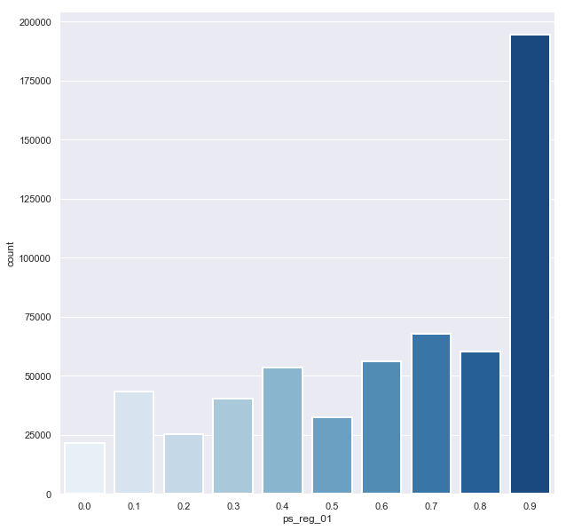

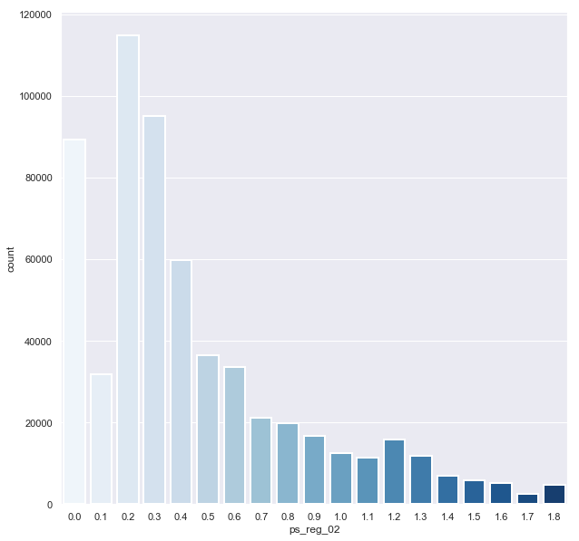

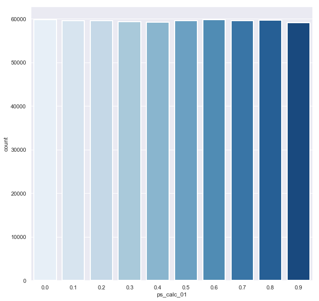

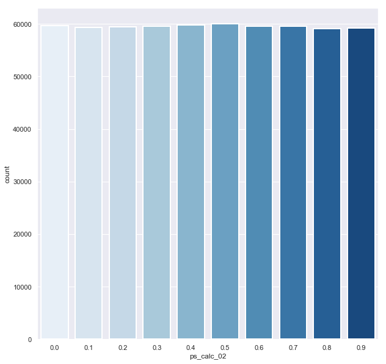

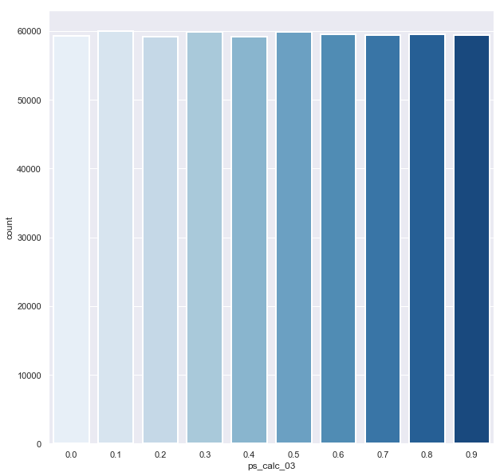

```python
# producing bar charts for selected variables
v = list(['ps_reg_01', 'ps_reg_02', 'ps_calc_01', 'ps_calc_02', 'ps_calc_03'])
sns.set( rc = {'figure.figsize': (10, 10)})

for f in v:
    plt.figure()
    sns.countplot(x = f, data = data, linewidth=2, palette="Blues")
    plt.show()
```

The variables `ps_calc_01`, `ps_calc_02`, `ps_calc_03` show an highly homogeneous distribution.

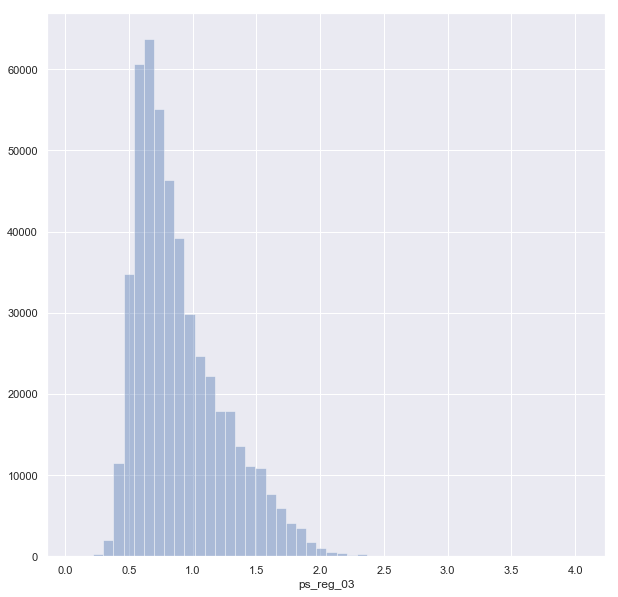

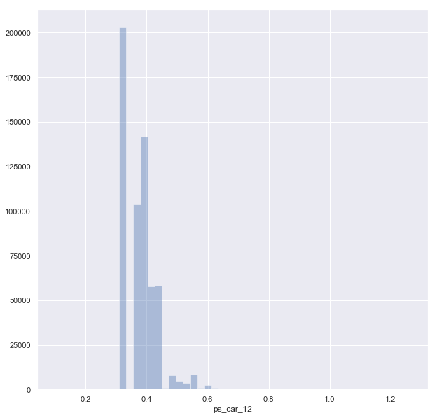

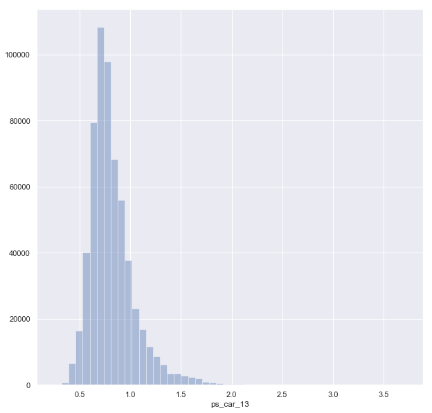

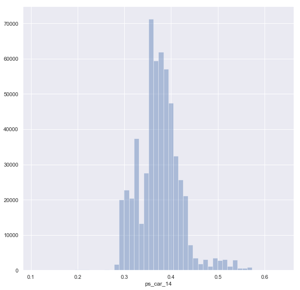

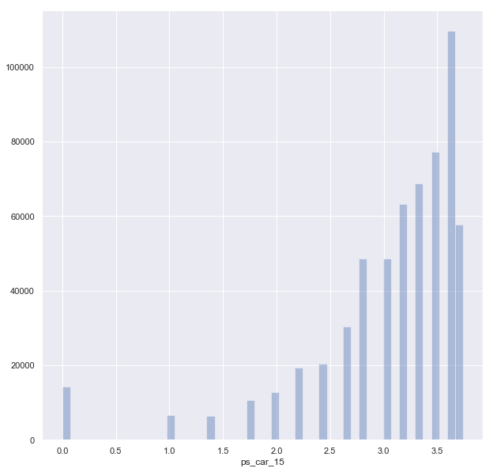

```python
# producing histograms for selected variables
v = list(['ps_reg_03', 'ps_car_12', 'ps_car_13', 'ps_car_14', 'ps_car_15'])
sns.set( rc = {'figure.figsize': (10, 10)})

for f in v:
    plt.figure()
    sns.distplot(data.loc[data[f] != -1, f], kde = False)
    plt.show()
```

Variables `ps_reg_03`, `ps_car_12`, `ps_car_13`, `ps_car_14` show distributions with right tails. Additional considerations on interval `car` variables are collected in the forthcoming section.

#### On interval `car` variables: `ps_car_12`, ..., `ps_car_15`

`car` variables are vehicle-related features, as stated in the Porto Seguro Kaggle challenge description. Therefore, it would interesting to inference on the nature of such variables, in the limits given by anonymization and lack of additional information. The most relevant case is represented by `ps_car_15`, which is obtained by square root of a feature with integer values

```python
squared = data['ps_car_15'] ** 2
squared.value_counts()
```

```
13.0    109765
12.0     77200
11.0     68737
10.0     63323
14.0     57757
8.0      48680
9.0      48537
7.0      30388
6.0      20445
5.0      19397
0.0      14186
4.0      12830
3.0      10744
1.0       6708
2.0       6515
Name: ps_car_15, dtype: int64
```

Therefore, one could suggest that `ps_car_15**2` represents the car manufacture age with 0.0 =2000, 1.0 = 2001,..., 14.0 =2014, but no final confirmation of the statement is possible. Going backwards, one can try squaring the remaining variables and try to map results to typical car-relevant information for insurance, i.e. CC, weight, value etc. for the purpose of feature selection. However, in absence of additional information on the provided `car` variables, no additional analysis is performed.

### Ordinal

The `16` ordinal variables are quickly displayed below. All variables except `ps_ind_01`, `ps_ind_03`, `ps_ind_14`, `ps_ind_15` and `ps_car_11` are of the `calc` type.

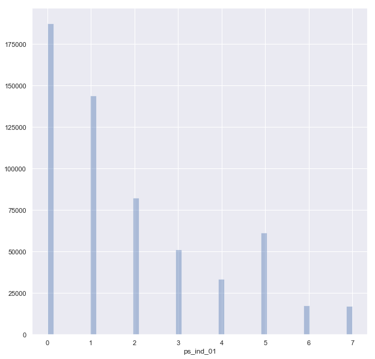

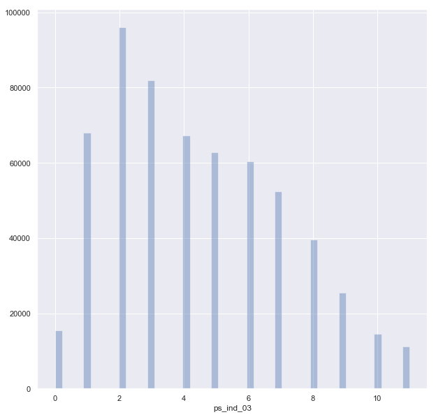

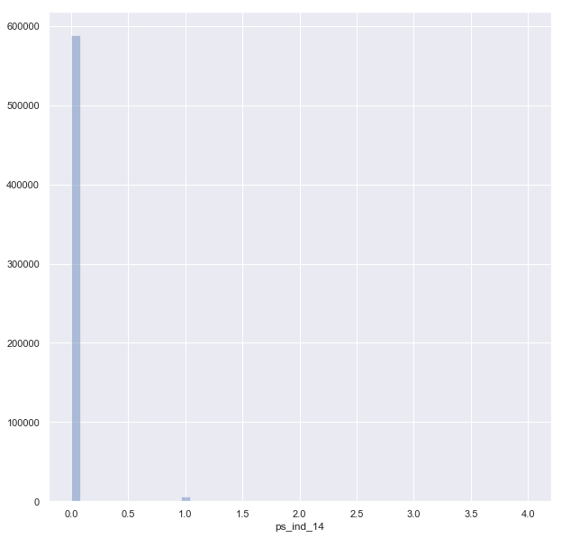

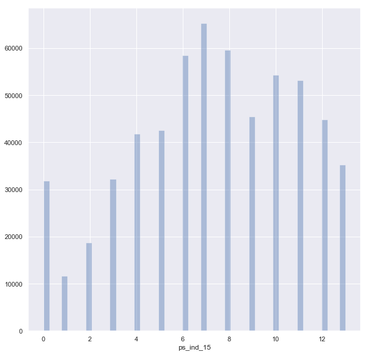

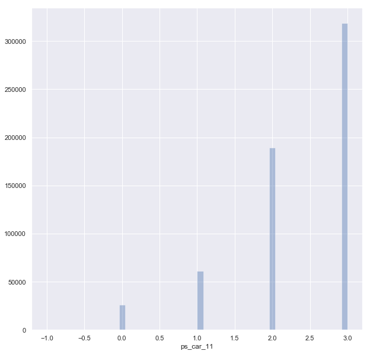

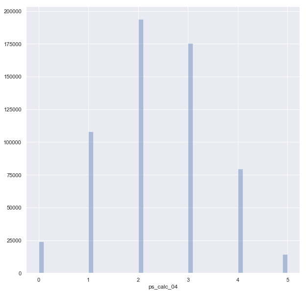

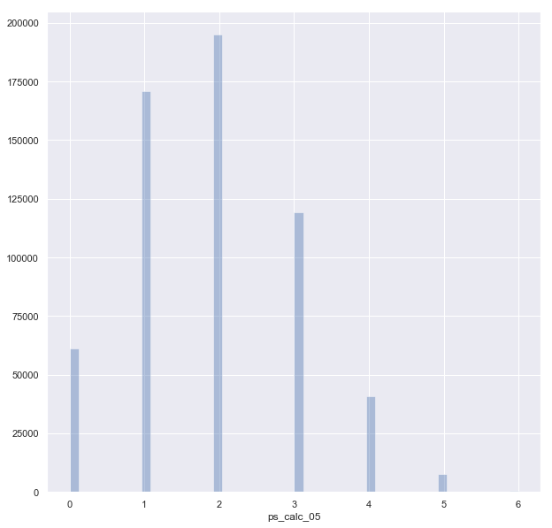

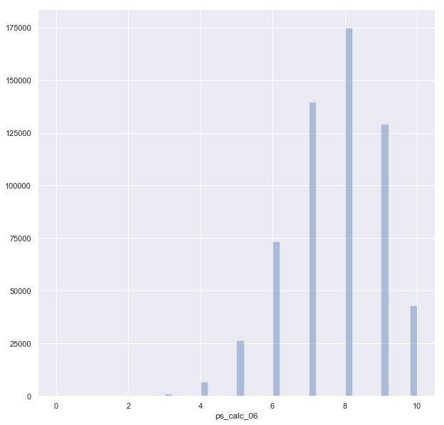

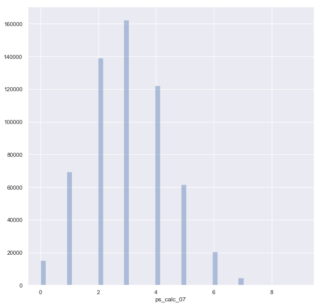

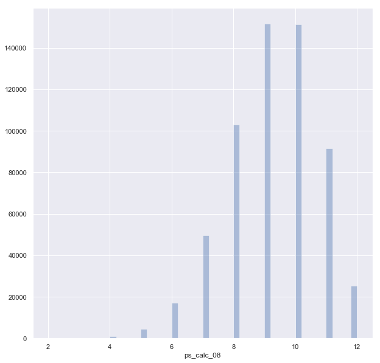

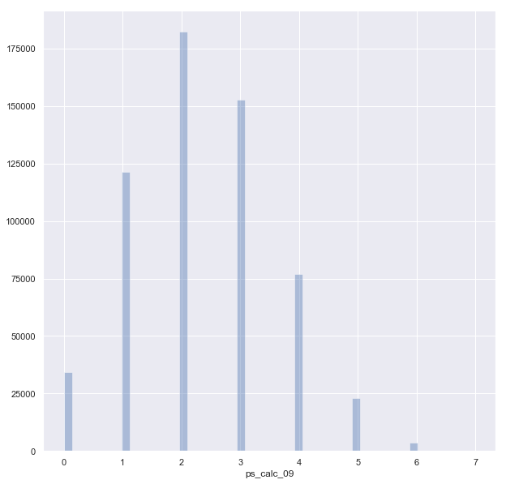

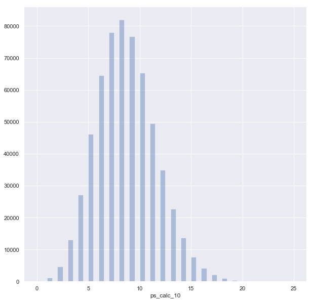

[4 more figures not shown]

```python
# ordinal features: visualization

# choose feature level
level = 'ordinal'

# producing histograms
v = meta[(meta.level == level) & (meta.keep)].index
sns.set( rc = {'figure.figsize': (10, 10)})

for f in v:
    plt.figure()

    sns.distplot(data[f], kde = False)
    plt.show()
```

`ps_ind_14` shows a strong skewness between ordinal levels, with concentration at `ps_ind_14 == 0` at 99% and monotonic decrease among levels. On the other hand, for `ps_car_11` the trend is monotone increasing. Level `5` in `ps_ind_01` breaks monotonicity. An overview of `ordinal` features is provided by tabulating the frequencies of levels, as done below.

```python
# ordinal features: tabulation

# creating the dictionary with feature level counts (missing values are dropped)
ctabs = {}
level = 'ordinal'

for f in meta[(meta.level == level) & (meta.keep)].index:
    ctabs[f] = ( pd.value_counts(data[f]) / data.shape[0] ) * 100

# printing the dictionary
for f in ctabs.keys():
    print(ctabs[f].round(2))
    print()
```

```
0    31.52
1    24.19
2    13.86
5    10.33
3     8.60
4     5.63
6     2.97
7     2.91
Name: ps_ind_01, dtype: float64

2     16.15
3     13.77
1     11.42
4     11.29
5     10.55
```

[output cut: 208 more lines]

## `target` variable: class imbalance

The `target` variable in the `data` dataset is highly imbalanced, as shown in the following code chunk:

```python
# levels for the target variable
lev_target = ( pd.crosstab(index = data['target'], columns = 'Frequency') / data.shape[0] ) * 100
lev_target.round(2)
```

| col_0 target | Frequency |
| --- | --- |
| 0 | 96.36 |
| 1 | 3.64 |

# Data Visualization and Multivariate Analysis

## Analysis of correlation for interval features

Pearson and Spearman correlation of interval variables is discussed.

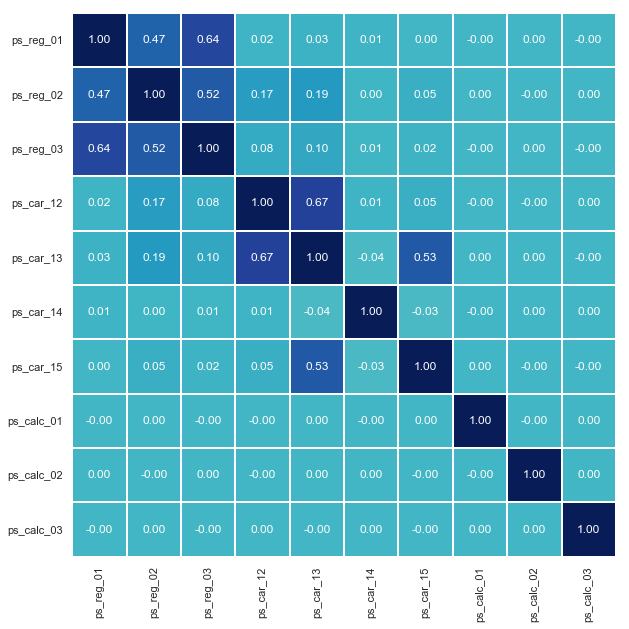

```python
# Pearson correlation matrix: computation and visualization

# use method='pearson' resp. method='spearman' to compute Pearson resp. Spearman correlations
def corr_heatmap(v):
    correlations = data[v].corr(method='pearson')
    fig = plt.subplots(figsize=(10, 10))

    sns.heatmap(correlations,  center=0, fmt='.2f', cbar=False,
                square=True, linewidths=1, annot=True,  cmap="YlGnBu")
    plt.xticks(rotation=90)
    plt.yticks(rotation=0)
    plt.show()

# one applies the corr_heatmap function on the interval features
v = meta[(meta.level == 'interval') & (meta.keep)].index
corr_heatmap(v)
```

Scatterplots of high correlation variables are provided below, instead (**warning**: computationally intensive visualization).

```
array([[<matplotlib.axes._subplots.AxesSubplot object at 0x0000024B24FDB048>,
      dtype=object)
```

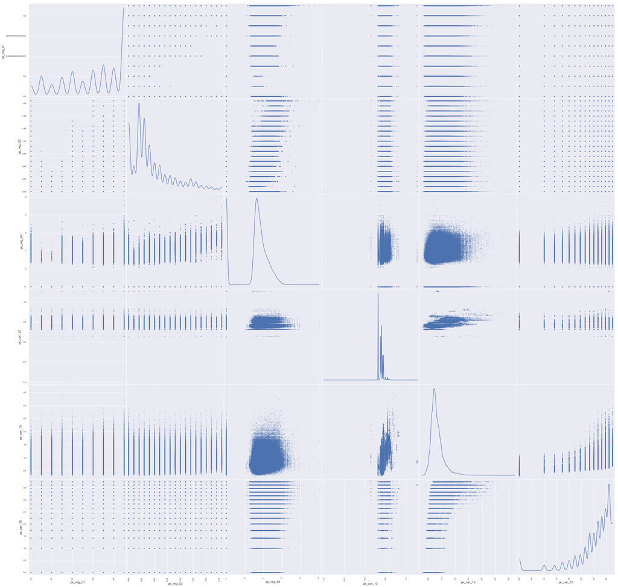

```python
# scatterplot high correlation interval variables
import seaborn
high = pd.Index(['ps_reg_01', 'ps_reg_02', 'ps_reg_03', 'ps_car_12', 'ps_car_13', 'ps_car_15'])
pd.plotting.scatter_matrix(data[high], alpha = 0.2, figsize = (40, 40), diagonal = 'kde')
```